# MI PRIMERA PAGINA WEB: para Damyta

Jhonny Heber

2020-09-16

Esta es la primera pagina web que creo con Rstudio y publicada a traves de GITHUB. La misma esta dedicada a Damyta, la mujer que amo mucho, y como ella diria de acuerdo a su definicion de amor, a la que **decidi** amarla, de estar a su lado, tratar de no hacerla renegar mucho, pero sobre todo de hacerla feliz todo con la bendicion de **DIOS**.

Se que lo mas importante para ella es que seamos guiados por la mano de Dios, lo tengo muy presente, pero aun no vamos a la iglesia, pero **LO HAREMOS**. No podriamos casarnos, claro despues de que me acepte, de otra forma que no sea bajo la mano de Dios.

Ella (Damyta) es una persona espectacular realmente sorprendente, llena de un muy buen corazon y justo, de fuertes principios y valores, de una inteligencia muy alta, al mismo tiempo de ser una hermosa mujer. Siempre pido que no cambie, que continue creciendo y aprendiendo mas cosas, siendo mas independiente como lo es ahora, al tiemppo de ser aun mas luchadora, es una mujer fuerte, que a pesar de probablemente derramar estres y ciertas lagrimas logra salir adelante con cualquier reto u oprtunidad que se le presente.

Asimismo, tiene una bella familia, a la que espero agradar, unos padres de igual forma lleno de principios y valores muy fuertes, luchadores, buenos entre otras cualdiades. De la misma forma, tiene un hermano y hermanas valorables que por todo lo que me cuenta ella la apoyan, se apoyan, entre todos, lo que demuestra la fortaleza de la familia.

Aqui vemos algunas fotitos de ella y de algunos momentos que pasamos:

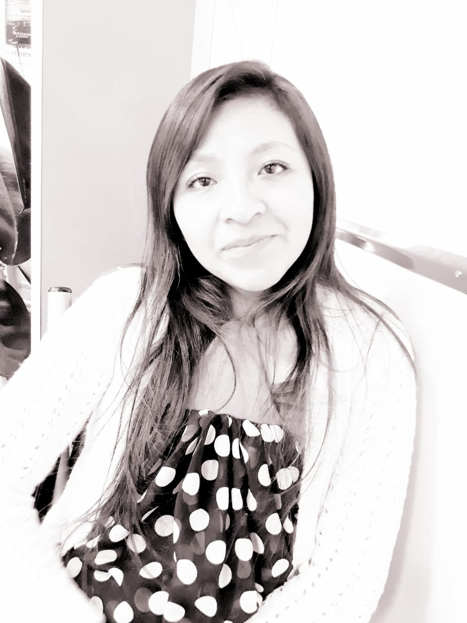

Esta es la primera foto que me permitio tomarle, fue cuando fuimos por unos silpanchos a SILPICH.

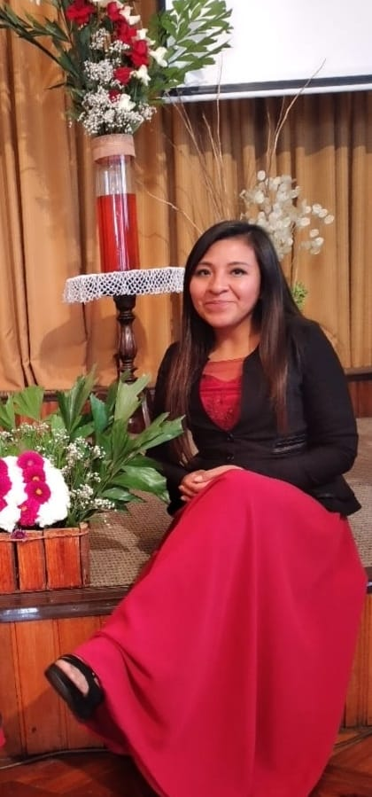

[figure not shown]

[figure not shown]

Tan hermosa **DAMYTA**

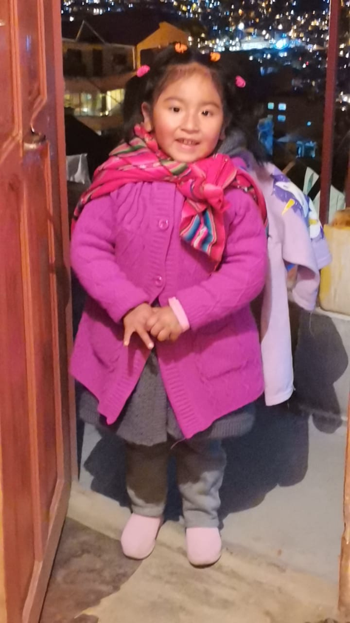

Su tierna y linda sobrinita.

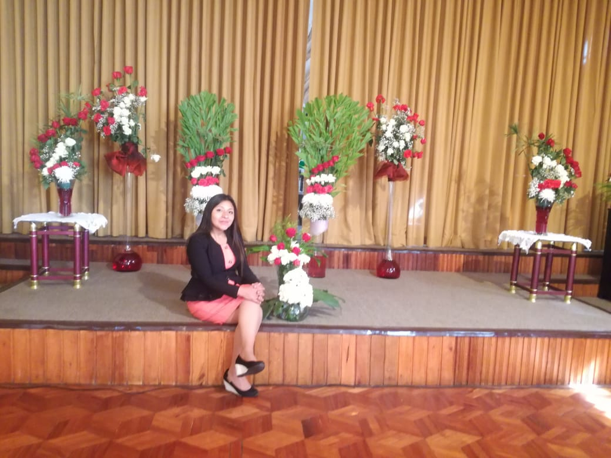

Ella en la iglesia.

Espero hacer bien las “cosas”, no fallarla, no fallarme, no fallar a Dios.